# Git tutorial

Febrary 2019

## Adobe readerをやめてGit+Githubにしたら捗った話

## はじめに

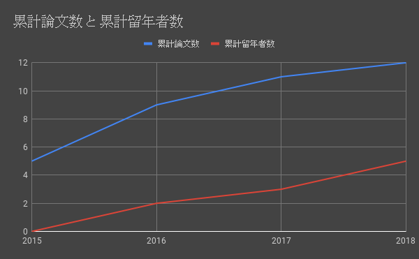

- 論文執筆作業の効率化が急務
- 論文執筆における作業の大半は添削と修正
- 添削の効率化が必要(手書きは論外=研究者の字は汚い)

## Adobe reader

修正箇所にハイライト(OR 取り消し線)を引いてコメントを書ける.

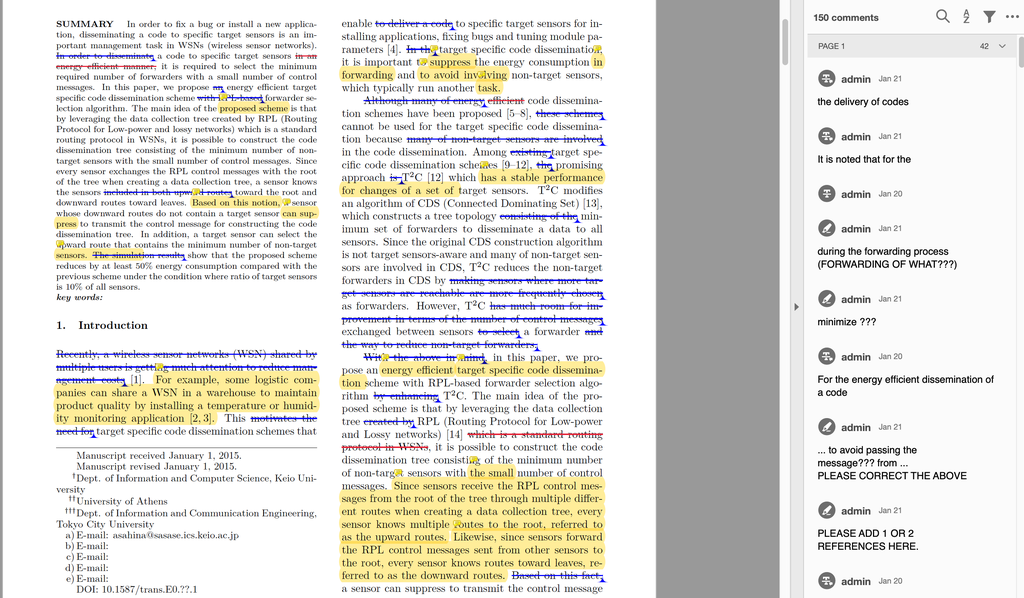

## Adobe readerの問題点

- **バージョン管理ができない**
  - バックアップしていても,どの原稿がいつのものかひと目でわからない.
  - そもそもマメにバックアップするのが面倒
  - コメントをもらった原稿と最新の原稿が食い違う
  - 以前の原稿からの変更箇所が分かりづらい
- **コメントを本文に反映するのが面倒**
  - (ただコピペするだけなのにPDFのコメント開いて,コピーして,原稿の該当箇所探して,削除して,貼り付けて…)
- **生のtexファイルが見えない**
  - ここマクロ使えば楽だよとかアドバイスできない

## Git + Github

バージョン管理ツールであるGitとGithubのIssue,Pull request(PR)のレビュー機能を用いることで,添削する側される側双方の負担を減らす事が可能.

- **backupが楽(Commitするだけ)**
- Commitのコメントを見れば,どのbackupがいつのものかひと目で分かる
- コメントをもらった原稿と最新の原稿が違ってもmergeできる
- **前の状態との差分が自動的に表示される(GithubのPRの機能)**
- **コメントの反映が楽**
  - PRのsuggestion機能を使えば,コメントをワンクリックで本文に反映してくれるため,コピペの手間が減る
- texに直接コメントできる(しかも見やすい)
- TODOを管理するIssueを使うことで,楽にタスクを振れる(振られた側もGoalが明確に示されるため楽)
- 一連の流れ
  1. (先輩) Issueを起てる (ゴールを明示する)
  2. (後輩) Issueに対応するBranchをmasterから切る
  3. (後輩) Issueを解決するCommitを作りPush,Pull request(PR)をmasterに出す
  4. (先輩) Pull requestをレビューする
  5. (後輩) レビューで指摘された箇所を修正するCommitを作りPushする (指摘がなければ6.へ進む)
  6. (先輩) 指摘箇所が修正されていることを確認して,PRをmasterへmergeする
  7. (先輩) いいね(e.g., 👍)を送って労う.

もちろん,原稿執筆だけでなく,ソースコードやVimの設定ファイルとかの管理にも使える.

Git使おう.

## git pushでやらかして頭が真っ白になった話

[git pushでやらかして頭が真っ白になった話](https://helen.hatenablog.com/entry/2015/11/03/001910)

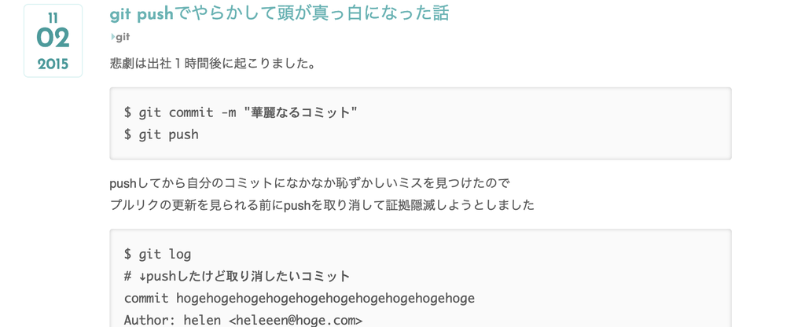

ちゃんと勉強してから使おう.

## Git

## 今日の趣旨

1. gitを覚える (頭で)
2. 呪文を覚える (身体で)
3. 呪文を打ち消す呪文を覚える (身体で)

2と3をひたすら繰り返す.

> 重犯罪人に自分の罪を思い知らせるなら、土を掘り移動させ、それからまた埋めて元に戻す、という作業を延々と繰り返させればよい。それは究極の拷問であり、最後には精神に異常をきたすであろう。(ドフトエフスキー?)

## 今日扱うcommandたち

##### 1つのbranchの操作

gitを使ったbackupの取り方

- git status
- git init
- git add
- git commit
- git reset
- git rm
- git mv
- git commit –amend
- git rebase -i

##### 複数のbranchの操作

複数のversionに分岐する場合を扱う  
(e.g., 研究会の原稿から国際会議と  
修論の原稿に分岐)

- git log
- git branch
- git checkout
- git merge
- git rebase

##### remote branchの操作

Cloudを利用して  
ユビキタス(死語)に使う.

- git clone
- git fetch
- git pull
- git push

## Gitってなんだよ

プログラムのソースコードなどの変更履歴を記録・追跡するための分散型バージョン管理システムだよ.

## 作った人

[figure not shown]

**リーナス・トーバルズ**

- Linux作った人(GitはLinux開発のためのツールとして作ったらしい)
- Linuxは修論で作ったらしい
- Gitは2週間くらいで作ったらしい
- 開発当時,有名なOSの教授とお互いのOSを貶し合ってめちゃくちゃ喧嘩したのが伝説になっている
- 今はContributerに暴言を吐きまくりながらLinux Kernelの開発を続けている
- 最近,人の気持を学んでくるとか言って自主謹慎した
- 優しい終身の独裁者(OSSコミュニティのリーダをこう呼ぶ)の一人
- 優しい…

## なにができんだよ

fileの変更履歴を保存しておいて,あとから好きな時点の状態に復元できるよ.

### Google driveでよくね?

よくない.

**Google driveでできないこと**

- RemoteとSyncするタイミングを制御できない(変更した瞬間*自動的*にSync)
  - 複数人で同じdirectoryの中身を編集できない
- directoryのバックアップに含めるfileを制御できない(*自動的*にバックアップ対象に追加される)
  - 設定ファイルはPCごとに別にしたいのでSyncしたくないとか思ってもできない

この2つの欠点のせいで,シミュレータが動く状態のdirectoryに戻したいとかいうことができない.

自動的(Automatic)はユーザから選択の自由を奪っている.

オートマ => 人権侵害

- これらができないがためにこうなりがち

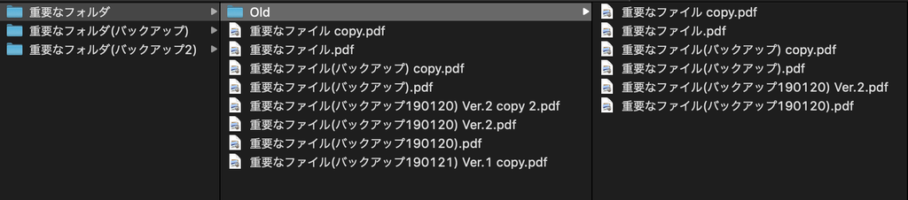

## 頭で覚えること

Gitには3つの視点がある

- Commit tree
- Three areas
- File status

これらを理解すればGit master.

## Commit tree

Commit (directoryのスナップショット)からなるツリー(一番重要).

- たくさんのスナップショット(バックアップ)を効率的に管理する方法と考えれば良い.
- CommitはdirectoryのスナップショットにIDとしてhash値を振ったもの.
- Commitには親となるCommitが記録されている (= ツリー構造)
- Hash値だけで管理すると人間が覚えられなくなってしまうのでHEADとかmasterみたいなタグを使う
- master, HEAD, branchなどは特定のCommitを指しているTag (Pointer)の名前(**重要**)
- 1度作ったcommitは基本的になくならない(探せなくはなるので注意)

[figure not shown]

### タグのイメージ

[figure not shown]

- 最後尾のCommit(人)は新しい人が並ぶたびに変わるが,最後尾は常に札の指す先にある.

### どういうときに思い出すべき?

- branchの操作 (branch, checkout, reset, rebase, push, pull)
- commitの操作 (reset, cherry-pick)

## Three areas

1つのCommitの裏には3つのレイヤがある

1. Working directory: 実際のdirectory
2. Staging Area (Index): Working direcoryのファイルのうちCommitに含まれる予定のファイルのcopy
3. git directory: Staging areaのfileがcopyされて来てスナップショットになる

[figure not shown]

もう少しわかりやすく

- Working directory:
  - 実際のDirectory
- Staging Area (Index):
  - これからBackupしたいファイルを一時的にCopyしておくところ
- git directory:
  - Backupを取るコマンドが実行されるとここに新しいDirectoryができてStaging areaのファイルがまるごと保存される.
  - ここにはこれまでのBackup direcotryが全部おいてある(Directorynの名前にはHashが自動的に振られる)

### どういうときに思い出すべき?

- 特定のCommitの変更 (reset, checkout)
- 特定のfileの操作 (add, rm, mv, reset, stash)

## File status

fileには4つの状態がある(three areasと合わせて覚えると良い)

1. Untracked: gitの追跡対象外のfile
2. Unmodified: gitの追跡対象で変更されていないfile(=Commitのfileと同じ)
3. Modified: gitの追跡対象で変更されたfile(=Commitのfileと違う)
4. Staged: gitの追跡対象で変更されたfileでStaging areaにcopy済みのもの

[figure not shown]

### どういうときに思い出すべき?

- 特定のfileの操作 (add, rm, mv, reset, stash)

## おめでとう

あなたは,gitマスターになりました.

## add, commit, reset

## git status

異世界に行ったら最初に唱える呪文.

File statusが4つのどの状態にあるかの確認.

```bash
# 準備
cd path/to/workspace
mkdir repo000
cd repo000
```

```bash
git status
```

これから何かする度になるべく`git status`しましょう.

### 思い出す

[figure not shown]

## git init

current directoryにgit repositoryを作る

```bash
git init
```

## git initをなかったことにする

current directoryからgit repositoryを削除する ! 削除したrepositoryは元に戻せないので注意

```bash
rm -R .git
```

## git add

ファイルをStaged areaに追加する.

- 新規ファイルの場合
  - tracked(gitの追跡対象指定)にする
  - staged(commitに含める対象指定)にする.
- 既存ファイルの場合
  - staged(commitに含める対象指定)にする.

`git add [path ...]`

```bash
echo "ROW000" > file000
git add file000
```

## git addをなかったことにする

- 新規ファイルの場合
  - untracked(gitの追跡対象外)にする
  - unstaged(commitに含める対象外)にする.
- 既存ファイルの場合
  - unstaged(commitに含める対象外)にする.

`git reset [--soft | --hard] [<commit>] [path ...]`

```bash
git reset HEAD file000
```

stage(git add)されたすべてのファイルを対象にしたい場合

```bash
git reset HEAD
```

## git commit

staged(git add)されたすべてのファイルのコピーをGit Directoryへ記録する

```bash
# 準備
git add file000
```

`git commit [--amend] [-m <msg>]`

```bash
git commit -m "Added file000."
```

## git commitをなかったことにする

Git Directoryから最後のCommitを削除する

```bash
# 準備
cp file000 file001
git add file001
git commit -m "Added file001."
```

```bash
git reset --soft HEAD^ # HEAD^ = 1つ前の親Commit
```

addもなかったことに

```bash
# 復習
git reset HEAD
```

commitとaddの2つをまとめてなかったことに

```bash
git reset HEAD^
```

## git commitをなかったことにしたのをなかったことに

```bash
$ git reflog
e170b24 (HEAD -> master) HEAD@{0}: reset: moving to HEAD^
953913d HEAD@{1}: commit: Added file001. <-- resetするまえのHEADの位置
...
```

```bash
git reset HEAD@{1} # HEAD@{1} = 1つ前にHEADの指していたcommit
```

## git reset

[interactive chart not shown]

**[やりなおせる Git 入門](https://www.slideshare.net/TomohikoHimura/git-22237343)** from **[Tomohiko Himura](https://www.slideshare.net/TomohikoHimura)**

|  | HEAD | インデックス | 作業ディレクトリ | 作業ディレクトリ保護の有無 |
| --- | --- | --- | --- | --- |
| **Commit Level** |  |  |  |  |
| `reset –soft [commit]` | REF | いいえ | いいえ | はい |
| `reset [commit]` | REF | はい | いいえ | はい |
| `reset –hard [commit]` | REF | はい | はい | **いいえ** |
| `checkout [commit]` | HEAD | はい | はい | はい |
| **File Level** |  |  |  |  |
| `reset (commit) [file]` | いいえ | はい | いいえ | はい |
| `checkout (commit) [file]` | いいえ | はい | はい | **いいえ** |

つまり?

`git reset --hard, git checkout <file>` (上表で太字の**いいえ**になっているやつ) するときは気をつけよう.

## rm, mv

## git rm –cached

ファイルをStaged areaとGit directoryから削除する

(=untracked(gitの追跡対象外)にする)

`git rm [--cached] [path ...]`

```bash
cd path/to/workspace
mkdir repo002
cd repo002
git init
echo "ROW000" > file000
git add file000
git commit -m "Added file000."
```

```bash
# 復習
git add file000 # tracked(gitの追跡対象指定)にする
```

```bash
git rm --cached file000
```

## .gitignore

一生untrackedにしておきたいfileやdirectoryは`,.gitignore`というfileを作ってそこに書く.

.gitignoreしたdirectory内の一部のfileのみをtrackedにしたい場合は,`.gitkeep`に書いてignoreされないようにする.

.gitignore(.gitkeep)については,自分でググってね. (i.e., あまり興味ない)

[figure not shown]

## git rm

ファイルをWorking Directory, Staged area, Git directoryのすべてから削除する.

```bash
# 準備
git add file000
```

```bash
rm file000
git add file000 # git rm --cached file000でも良い
git commit -m "Removed file000."
```

上の2つをまとめてやる

```bash
# 準備
git reset --hard HEAD^ # HEAD^ = 1つ前の親Commit
```

```bash
git rm file000
git commit -m "Removed file000."
```

## git mv

ファイルをWorking Directory, Staged area, Git directoryのすべてにおいてmoveまたはrenameする.

*Note: mvとrenameは本質的に同じ*

`git mv <source> <destination>`

```bash
# 準備
git reset --hard HEAD^
```

```bash
git mv file000 file001
git commit -m "Renamed file000 to file001."
```

## commit –amend, rebase

## git commit –amend

最後のCommitを変更する

```bash
# 準備
cd path/to/workspace
mkdir repo003
git init
echo "ROW000" > file000
cp file000 file001
git add file000
git commit -m "Added file000."
```

ファイルをaddし忘れたときとか,コメントを修正したい時とかに便利

```bash
git add file001
git commit --amend -m "Added file000 and file001."
```

## git rebase

直前だけじゃなく,もっと前まで遡って自分の都合の良いように歴史を改変したい

`git rebase -i <commit>`

`<commit>`から`HEAD`までのコミットをまとめて変更する

```bash
# 準備
rm -rf *
echo "ROW000" > file000
git commit -a -m "Added file000."
for f in file001 file002 file003 gomi; do cp file000 $f; done
# file001, file002, file003, gomiができれば何でも良い
git add file001
git commit -m 'Added file001.'
git add file002
git commit -m 'Added file002.'
git add file003
git commit -m '「もしかして:再帰」をクリックすると「もしかして:再帰」が表示される'
git add gomi
git commit -m 'Added gomi.'
```

`git rebase -i <commit>`

```bash
* bf1b31a (HEAD -> master) Added gomi. #
* fb7cc7b 「もしかして:再帰」をクリックすると「もしかして:再帰」が表示される # <-- HEAD~1 or HEAD^
* 469a642 Added file002. # <-- HEAD~2 or HEAD^^
* f8c8773 Added file001. # <-- HEAD~3 or HEAD^^^
* 2312317 Added file000. # <-- HEAD~4 or HEAD^^^^
```

`<commit>`には変更の根本となるcommitを指定する.

```bash
git rebase -i HEAD~4 # HEAD~4 = 4つ前の親Commit
```

この場合変更対象は`HEAD` - `HEAD~3`

```bash
pick 17b9da7 Added file001.
pick 98ee317 Added file002.
pick 9a7d9db 「もしかして:再帰」をクリックすると「もしかして:再帰」が表示される
pick 00805cf Added gomi.

# Rebase e170b24..00805cf onto e170b24 (4 commands)
#
# Commands:
# p, pick = use commit
# r, reword = use commit, but edit the commit message
# e, edit = use commit, but stop for amending
# s, squash = use commit, but meld into previous commit
# f, fixup = like "squash", but discard this commit's log message
# x, exec = run command (the rest of the line) using shell
# d, drop = remove commit
#
# These lines can be re-ordered; they are executed from top to bottom.
#
# If you remove a line here THAT COMMIT WILL BE LOST.
#
# However, if you remove everything, the rebase will be aborted.
#
# Note that empty commits are commented out
```

1番目と2番目はまとめたくて,3番目のメッセージを書き直したくて,4番目は消したい.

```bash
pick 17b9da7 Added file001.
s 98ee317 Added file002.
e 9a7d9db 「もしかして:再帰」をクリックすると「もしかして:再帰」が表示される
d 00805cf Added gomi.

# Rebase e170b24..00805cf onto e170b24 (4 commands)
#
# Commands:
# p, pick = use commit
# r, reword = use commit, but edit the commit message
# e, edit = use commit, but stop for amending
# s, squash = use commit, but meld into previous commit
# f, fixup = like "squash", but discard this commit's log message
# x, exec = run command (the rest of the line) using shell
# d, drop = remove commit
#
# These lines can be re-ordered; they are executed from top to bottom.
#
# If you remove a line here THAT COMMIT WILL BE LOST.
#
# However, if you remove everything, the rebase will be aborted.
#
# Note that empty commits are commented out
```

```bash
# This is a combination of 2 commits.
# This is the 1st commit message:

Added file001.

# This is the commit message #2:

Added file002.

# Please enter the commit message for your changes. Lines starting
# with '#' will be ignored, and an empty message aborts the commit.
#
# Date:      Sat Feb 16 22:50:41 2019 +0900
#
# interactive rebase in progress; onto e170b24
# Last commands done (2 commands done):
#    pick 5b6d77f Added file001.
#    squash 21c25a0 Added file002.
# Next commands to do (2 remaining commands):
#    edit 2f734eb 「もしかして:再帰」をクリックすると「もしかして:再帰」が表示される
#    drop cf942f2 Added gomi.
# You are currently rebasing branch 'master' on 'e170b24'.
#
# Changes to be committed:
#       new file:   file001
#       new file:   file002
```

```bash
# This is a combination of 2 commits.
# This is the 1st commit message:

Added file001 and file002.

# This is the commit message #2:

# Added file002.

# Please enter the commit message for your changes. Lines starting
# with '#' will be ignored, and an empty message aborts the commit.
#
# Date:      Sat Feb 16 22:50:41 2019 +0900
#
# interactive rebase in progress; onto e170b24
# Last commands done (2 commands done):
#    pick 5b6d77f Added file001.
#    squash 21c25a0 Added file002.
# Next commands to do (2 remaining commands):
#    edit 2f734eb 「もしかして:再帰」をクリックすると「もしかして:再帰」が表示される
#    drop cf942f2 Added gomi.
# You are currently rebasing branch 'master' on 'e170b24'.
#
# Changes to be committed:
#       new file:   file001
#       new file:   file002
```

```bash
[detached HEAD 0136ee2] Added file001 and file002.
 Date: Sat Feb 16 22:50:41 2019 +0900
 2 files changed, 2 insertions(+)
 create mode 100644 file001
 create mode 100644 file002
Stopped at 2f734eb...  「もしかして:再帰」をクリックすると「もしかして:再帰」が表示される
You can amend the commit now, with

  git commit --amend # <-- commitを編集したいのでまずは,こっち

Once you are satisfied with your changes, run

  git rebase --continue
```

git logを見てみると`<commit>`で指定した根本から枝分かれしていることがわかる

```bash
$ git log --oneline --graph --all
* 87449ac (HEAD) 「もしかして:再帰」をクリックすると「もしかして:再帰」が表示される
* 2f98c92 Added file001 and file002.
| * bf1b31a (master) Added gomi.
| * fb7cc7b 「もしかして:再帰」をクリックすると「もしかして:再帰」が表示される
| * 469a642 Added file002.
| * f8c8773 Added file001.
|/
* 2312317 Added file000.
```

```bash
git commit --amend
```

```bash
「もしかして:再帰」をクリックすると「もしかして:再帰」が表示される

# Please enter the commit message for your changes. Lines starting
# with '#' will be ignored, and an empty message aborts the commit.
#
# Date:      Sat Feb 16 22:50:41 2019 +0900
#
# interactive rebase in progress; onto e170b24
# Last commands done (3 commands done):
#    squash 21c25a0 Added file002.
#    edit 2f734eb 「もしかして:再帰」をクリックすると「もしかして:再帰」が表示される
# Next command to do (1 remaining command):
#    drop cf942f2 Added gomi.
# You are currently editing a commit while rebasing branch 'master' on 'e170b24'.
#
# Changes to be committed:
#       new file:   file003
#
```

```bash
Added file003.

# Please enter the commit message for your changes. Lines starting
# with '#' will be ignored, and an empty message aborts the commit.
#
# Date:      Sat Feb 16 22:50:41 2019 +0900
#
# interactive rebase in progress; onto e170b24
# Last commands done (3 commands done):
#    squash 21c25a0 Added file002.
#    edit 2f734eb 「もしかして:再帰」をクリックすると「もしかして:再帰」が表示される
# Next command to do (1 remaining command):
#    drop cf942f2 Added gomi.
# You are currently editing a commit while rebasing branch 'master' on 'e170b24'.
#
# Changes to be committed:
#       new file:   file003
#
```

終わったらcontinue

```bash
git rebase --continue
```